# AssetAllocation

Jinwon Lee

2021 2 21

# 1. 들어가며

역사적으로 버블 붕괴, 부도, 경제 위기 같은 사건들은 언젠가 반드시 일어났고, 그때마다 가장 흔한 투자 대상으로 여겨지는 주식 시장은 폭락을 맞이했습니다. -50%를 만회하려면 100% 수익을 내야만 하는데, 이것은 어려운 일입니다. 게다가, -50%를 당하고서도 시장에 남아있을 수 있는 사람은 거의 없습니다. 그러나, 처음부터 적게 잃는 방향으로 간다면 부담이 줄어듭니다. -20%를 만회하려면 25% 수익을 내야 합니다. 손실을 2.5배 줄이면 만회하는 데 필요한 수익률은 1/4이면 됩니다. 또한, 당한 손실이 적어지므로 시장을 완전히 떠나 회복 기회를 잃는 것을 방지합니다. 이런 구조를 만들기 위해서는 주식 시장이 폭락할 때 막아줄 자산이 필요한데, 주식 시장과 상관관계가 낮거나 음의 상관관계를 가지는 자산에 분산 투자를 하면 됩니다. 이런 방식이 자산배분 투자입니다. 자산배분은 자산군 배분 외에도 국가 배분도 가능합니다. 저는 투자 전략은 하락장에서 시장보다 방어를 잘하고 위험 대비 수익이 높다면 성공적인 전략이라고 생각합니다. 각 자산군들의 과거 수익률 데이터에서 언제 폭락이 발생했는지 보겠습니다. 백테스트에 필요한 라이브러리들을 불러옵니다.

```r
library(dplyr)
library(reshape2)
library(quantmod)
library(PerformanceAnalytics)
library(readxl)
library(xts)
library(magrittr)
library(lubridate)
library(tidyr)
library(ggplot2)
library(quadprog)
library(corrplot)
library(cccp)
library(fPortfolio)
library(nloptr)
library(PortfolioAnalytics)
```

# 2. 자산군별 과거 결과

데이터는 S&P 500과 T-Bill 등의 자산군은 1900년부터의 월간 수익률 데이터를 가지고 있고, 그 외의 자산군도 상당히 긴 기간의 데이터를 대상으로 합니다.

수익률 계산과 각종 성과 지표 계산에는 PerformanceAnalytics 라이브러리를 사용합니다. 먼저 1900년 1월부터의 누적 수익률과 연간 복리(기하) 수익률을 계산합니다. 아래에서 사용하는 ReturnTimeSeries는 ReturnData를 xts 패키지를 사용해 시계열 데이터로 변환한 것입니다. PerformanceAnalytics 라이브러리의 Return.cumulative 패키지는 연율화 계산을 위해 (1+r1)x(1+r2)x…x(1+rn)-1 형태의 값을 제공하고 있고, chart.CumReturns 함수도 같은 방식이므로 감안하여 살펴보겠습니다.

## 2.1. 주식

### 2.1.1. S&P 500 (미국 대형주)

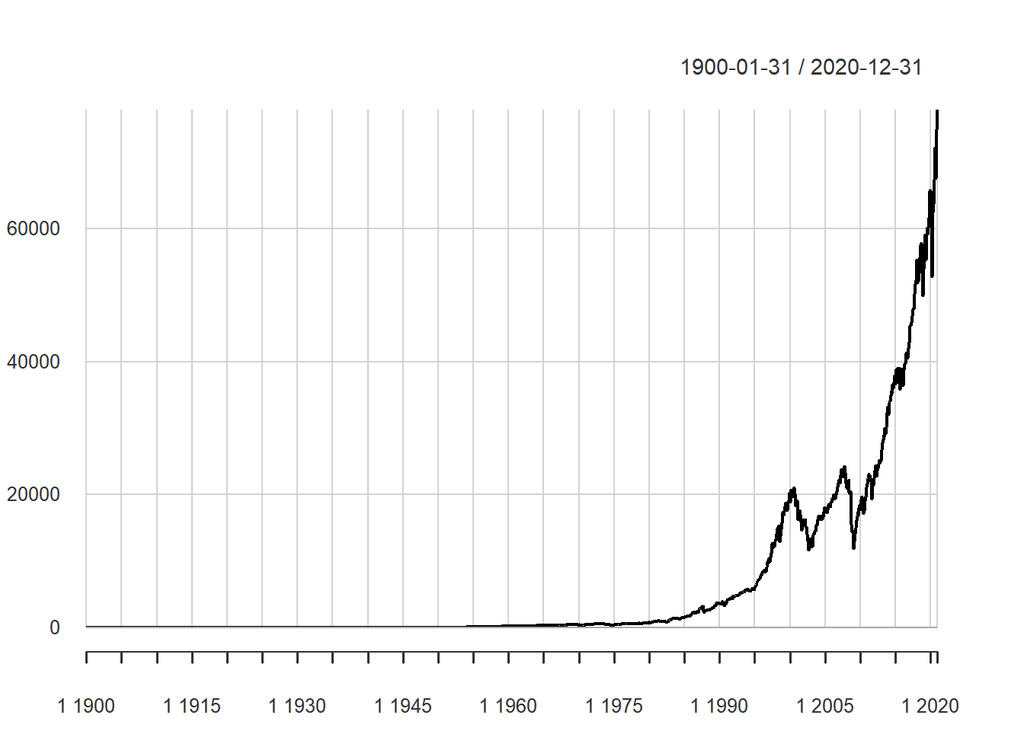

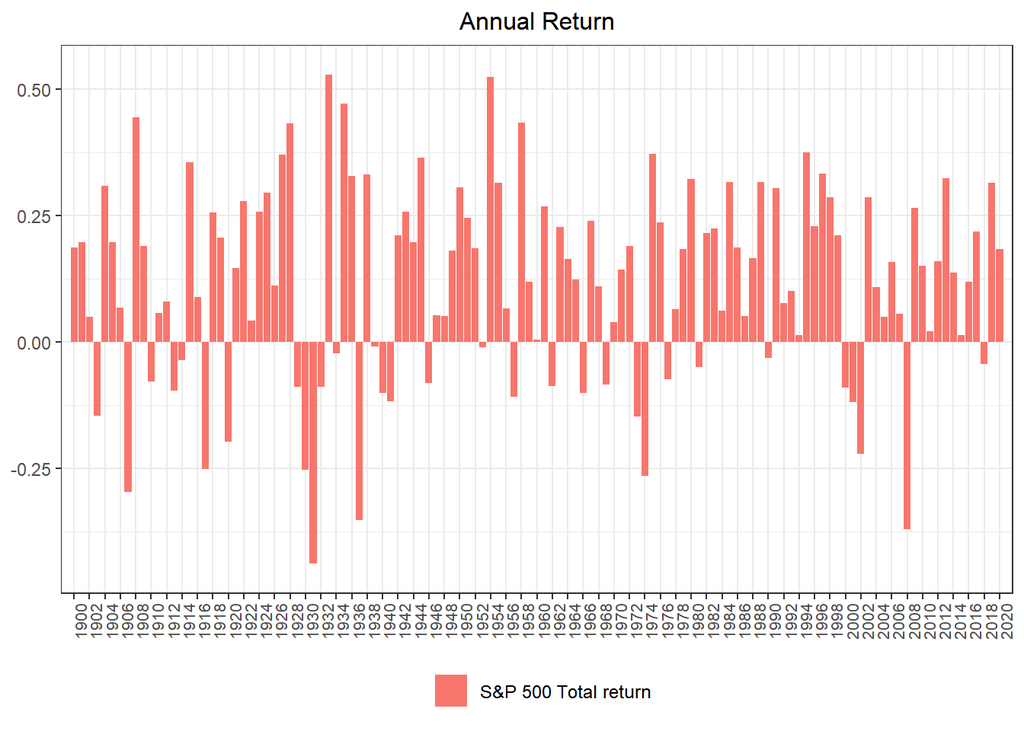

표 1: S&P 500 지수 수익률: 1900.01 ~ 2020.12

| 누적 수익 | 연복리 수익률 |
| --- | --- |
| 77822배 | 9.75% |

```r
Return.cumulative(ReturnTimeSeries$`S&P 500 Total return`)
Return.annualized(ReturnTimeSeries$`S&P 500 Total return`)
chart.CumReturns(ReturnTimeSeries$`S&P 500 Total return`)
```

S&P 500은 121년 동안 누적 수익률 기준 원금의 77822배가 되었고, 연복리 수익률은 9.75%가 나옵니다. 121년 동안의 결과로만 보면 미국에 돈을 맡기고 아무것도 안 하는 것은 매우 현명한 선택이었습니다. 이번에는 S&P 500 외에 선진국 주식, 신흥국 주식, 전세계 주식의 과거 수익률을 보겠습니다.

### 2.1.2. MSCI EAFE (미국 외 선진국)

먼저 선진국 주식입니다. 선진국 주식은 1970년 1월부터의 데이터입니다. 70년대 오일 쇼크에서 비롯된 강력한 인플레이션 시기를 포함하고, 1980년부터의 대세 금리 인하기를 같이 포함하므로 테스트에 사용하기에는 충분한 기간입니다.

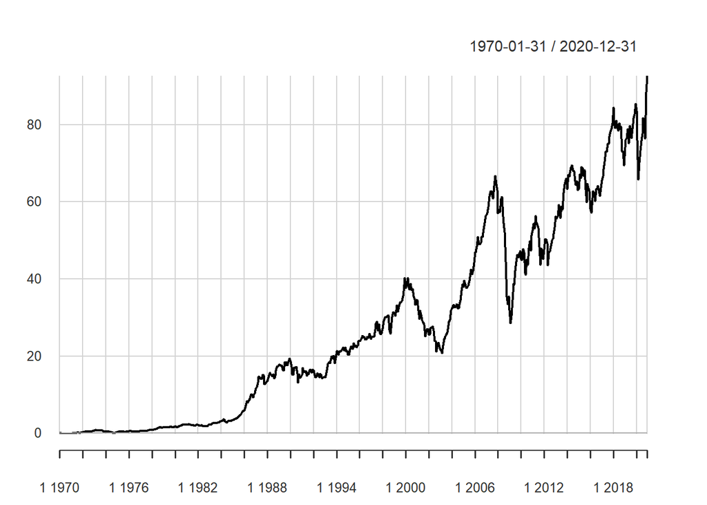

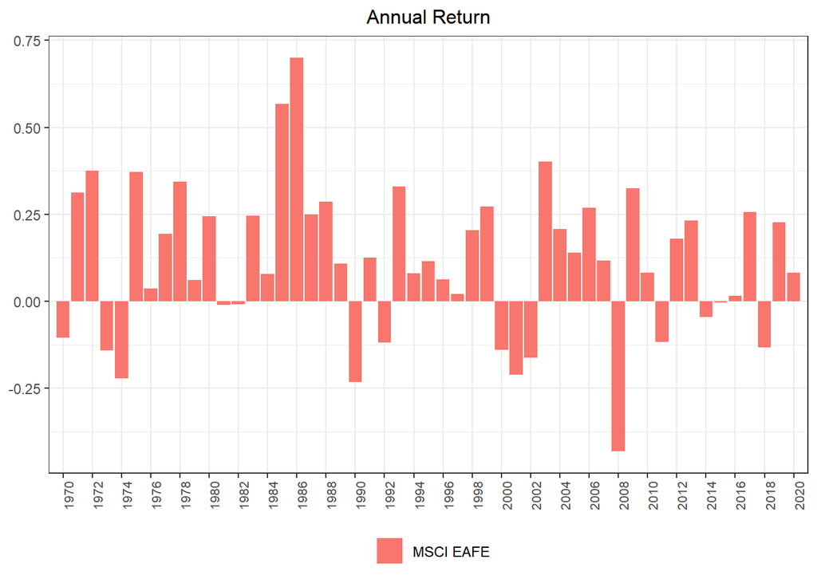

표 2: MSCI EAFE 지수 (미국 외 선진국) 수익률: 1970.01 ~ 2020.12

| 누적 수익 | 연복리 수익률 |
| --- | --- |
| 93.61배 | 9.31% |

```r
Return.cumulative(ReturnTimeSeries$`MSCI EAFE`)
Return.annualized(ReturnTimeSeries$`MSCI EAFE`)
chart.CumReturns(ReturnTimeSeries$`MSCI EAFE`)
```

선진국 주식은 51년 동안 누적 수익률 기준 원금의 93.61배가 되었고, 연복리 수익률은 9.31%가 나옵니다. 미국 S&P 500보다는 약간 못하지만 그래도 훌륭합니다. 다음은 신흥국 주식입니다. 신흥국 주식은 1926년 1월부터의 데이터입니다.

### 2.1.3. EEM (신흥국)

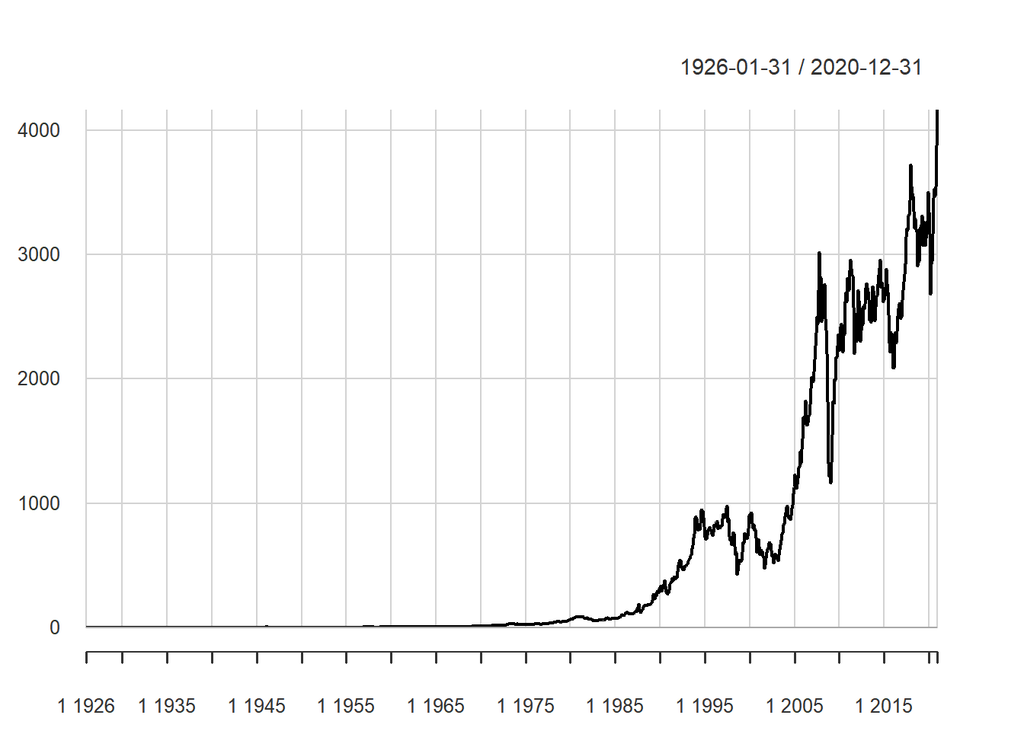

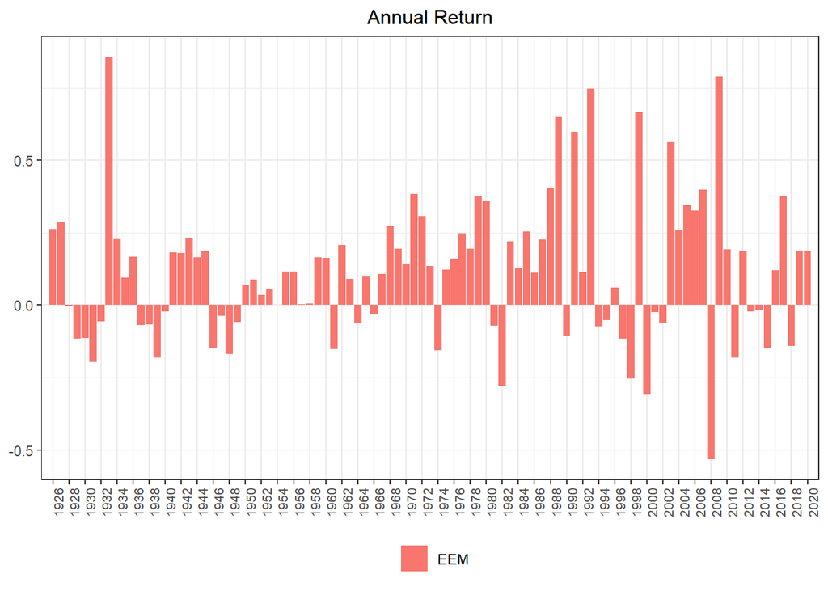

표 3: EEM (신흥국) 수익률: 1926.01 ~ 2020.12

| 누적 수익 | 연복리 수익률 |
| --- | --- |
| 4163배 | 9.17% |

```r
Return.cumulative(ReturnTimeSeries$EEM)
Return.annualized(ReturnTimeSeries$EEM)
chart.CumReturns(ReturnTimeSeries$EEM)
```

신흥국 주식은 95년 동안 누적 수익률 기준 원금의 4163배가 되었고, 연복리 수익률은 9.17%가 나옵니다. 주식 시장에 투자를 한다면 미국, 선진국, 신흥국 관계없이 데이터 기간 동안 연복리 9% 수준의 수익률이 나오고 있습니다. 그러므로, 포트폴리오 구성에서 주식을 제외하고는 안정적으로 괜찮은 수익률을 달성할 가능성이 매우 낮습니다. 마지막으로 전세계 주식입니다. 전세계 주식도 1926년 1월부터의 데이터입니다.

### 2.1.4. World Stocks (전세계 주식)

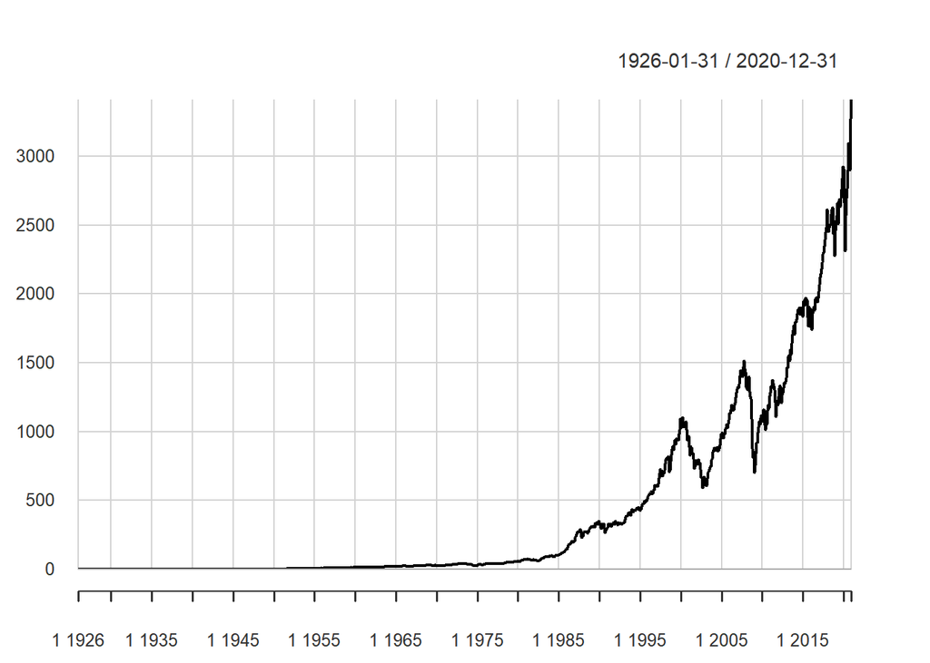

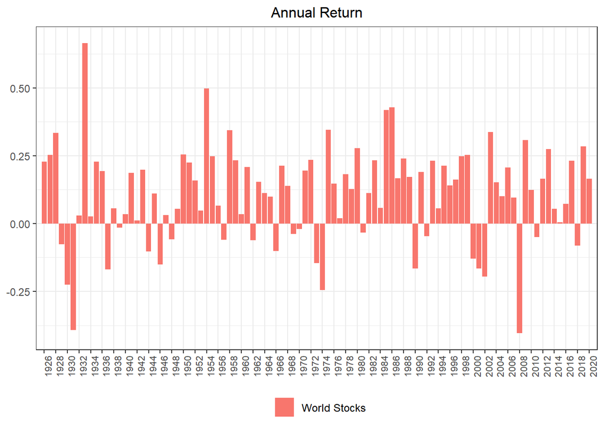

표 4: 전세계 주식 수익률: 1926.01 ~ 2020.12

| 누적 수익 | 연복리 수익률 |
| --- | --- |
| 3410배 | 8.94% |

```r
Return.cumulative(ReturnTimeSeries$`World Stocks`)
Return.annualized(ReturnTimeSeries$`World Stocks`)
chart.CumReturns(ReturnTimeSeries$`World Stocks`)
```

전세계 주식은 95년 동안 누적 수익률 기준 원금의 3410배, 연복리 수익률은 8.94%가 나옵니다. 미국, 선진국, 신흥국, 전세계 모두 장기적으로 연 9% 근처로 수렴하는 것처럼 보입니다.

## 2.2. 국채

### 2.2.1. 10년 만기 국채

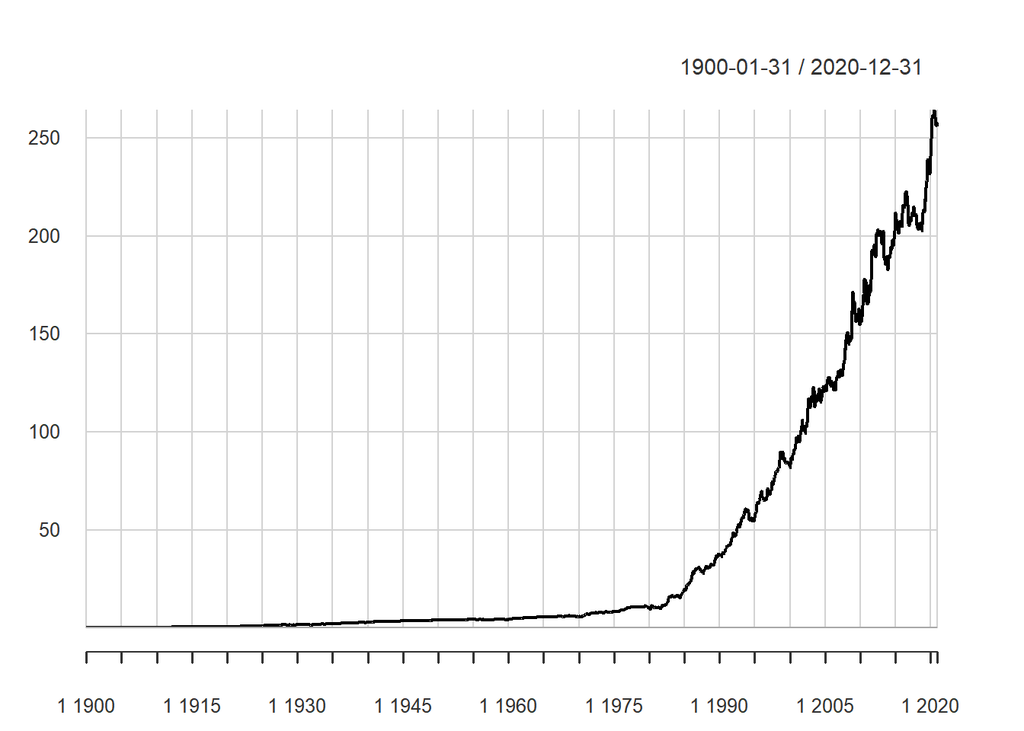

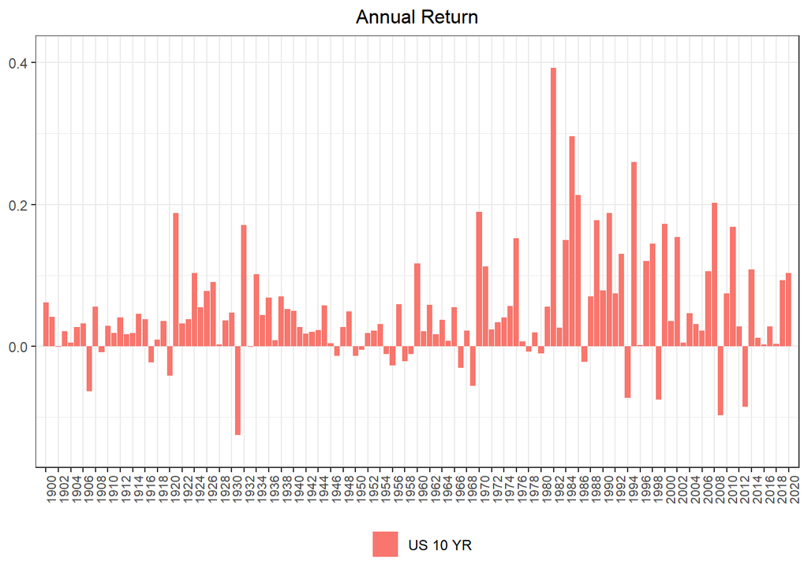

표 5: 10년 만기 국채 수익률: 1900.01 ~ 2020.12

| 누적 수익 | 연복리 수익률 |
| --- | --- |
| 256.89배 | 4.69% |

```r
Return.cumulative(ReturnTimeSeries$`US 10 YR`)
Return.annualized(ReturnTimeSeries$`US 10 YR`)
chart.CumReturns(ReturnTimeSeries$`US 10 YR`)
```

10년 만기 국채는 누적 수익률 기준 원금의 256.89배가 나오고, 연복리 수익률은 4.69% 입니다. 만기가 꽤 길어서 투자 대상으로 삼을 수 있는 정도의 수익률이 나오고 있습니다.

### 2.2.2. 30년 만기 국채

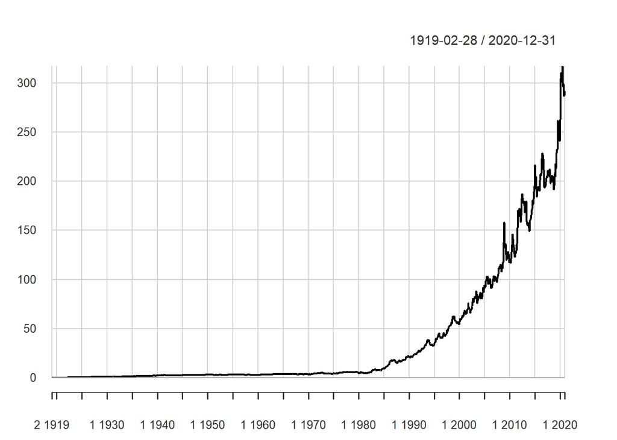

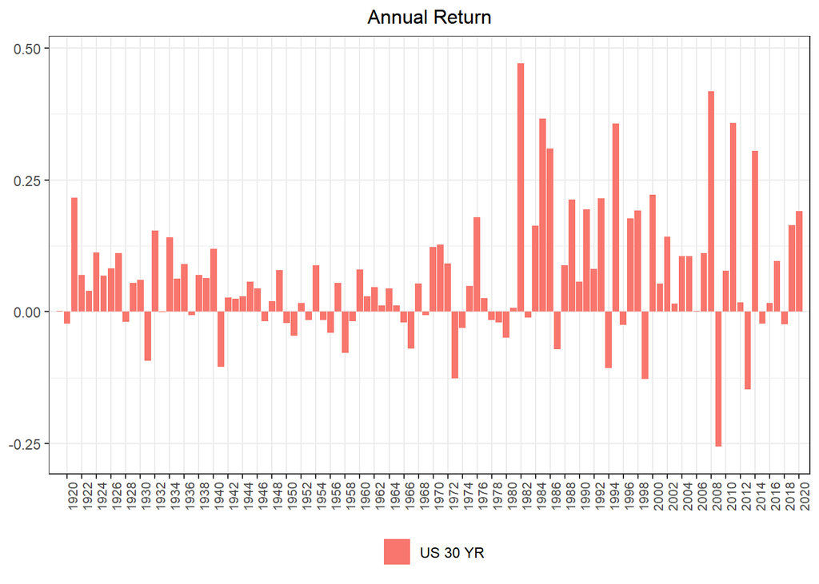

표 6: 30년 만기 국채 수익률: 1919.02 ~ 2020.12

| 누적 수익 | 연복리 수익률 |
| --- | --- |
| 288.43배 | 5.72% |

```r
Return.cumulative(ReturnTimeSeries$`US 30 YR`)
Return.annualized(ReturnTimeSeries$`US 30 YR`)
chart.CumReturns(ReturnTimeSeries$`US 30 YR`)
```

30년 만기 국채는 누적 수익률 기준 원금의 288.43배가 나오고, 연복리 수익률은 5.72%가 나옵니다. 만기가 길어지니 수익률도 증가했습니다.

## 2.3. 상관관계

다음으로는 상관관계를 보겠습니다. 선진국 주식의 데이터 기간이 짧으니 선진국 주식을 포함한 것과 포함하지 않은 경우로 보겠습니다. 먼저, 선진국 주식을 포함한 경우입니다. 상관관계를 보기 위해 시계열 변환 전 데이터를 사용했습니다.

```r
cor(subset(ReturnData, select=c('T-Bills', 'S&P 500 Total return', 'MSCI EAFE', 'EEM', 'World Stocks', 'US 10 YR',
                                'US 30 YR')), use='complete.obs')
```

```
##                          T-Bills S&P 500 Total return    MSCI EAFE         EEM
## T-Bills               1.00000000          -0.01640156 -0.014318565 -0.01899857
## S&P 500 Total return -0.01640156           1.00000000  0.653525611  0.52860791
## MSCI EAFE            -0.01431857           0.65352561  1.000000000  0.62913074
## EEM                  -0.01899857           0.52860791  0.629130739  1.00000000
## World Stocks         -0.02546581           0.89621806  0.911764794  0.63082752
## US 10 YR              0.03167929           0.06279178 -0.001460894 -0.10411439
## US 30 YR             -0.02467908           0.04454364 -0.036195749 -0.12430468
##                       World Stocks     US 10 YR      US 30 YR
## T-Bills              -0.0254658089  0.031679288 -0.0246790770
## S&P 500 Total return  0.8962180588  0.062791782  0.0445436439
## MSCI EAFE             0.9117647938 -0.001460894 -0.0361957487
## EEM                   0.6308275158 -0.104114390 -0.1243046825
## World Stocks          1.0000000000  0.030526493  0.0007687633
## US 10 YR              0.0305264931  1.000000000  0.8289238687
## US 30 YR              0.0007687633  0.828923869  1.0000000000
```

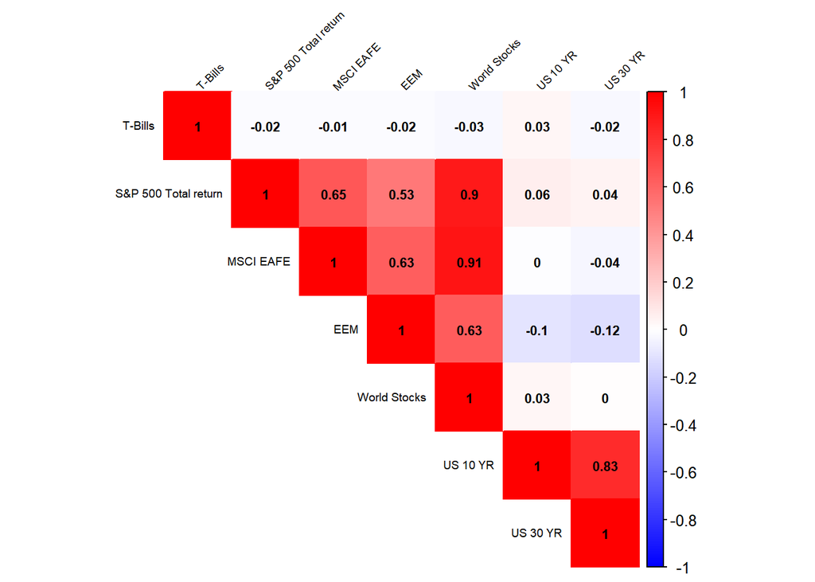

MSCI EAFE가 들어갔으므로 1970년부터의 상관관계입니다. 미국 단기 국채인 T-Bills는 현금과 비슷한 역할을 할 수 있으므로, 다른 주가지수, 국채와 상관관계가 거의 없습니다. 현금 100%는 인플레이션 조정 시 구매력의 감소를 가져오는 문제가 있지만, 자산배분 측면에서는 현금을 일정 수준 가져감으로써 포트폴리오의 다각화 수준을 높일 수 있을 것입니다. 일반적으로는 주식과 국채는 반대 방향으로 움직인다고 알려져 있습니다. 그러나, 1970년부터의 상관관계를 보면 S&P 500 지수와 미국 10년 만기 국채의 상관계수 0.06, 30년 만기 국채와의 상관계수 0.04으로 반대 방향보다는 상관관계가 거의 없다고 보여집니다. 주식과 국채는 상관관계가 낮은 자산군이므로, 두 자산군을 포트폴리오에 같이 포함시켜 다각화 수준을 높일 수 있습니다. 주가 지수끼리의 상관계수는 S&P 500과 선진국 지수는 0.65, S&P 500과 신흥국 지수는 0.53으로 나타납니다. 전세계 지수는 S&P 500 지수와 0.9, 선진국 지수와 0.91의 상관계수가 나오므로, 미국과 선진국 위주로 만들어진 지수라고 추측할 수 있습니다. 다음으로는 선진국 주식을 제외해서 1926년부터의 상관계수를 보겠습니다.

```r
cor(subset(ReturnData, select=c('T-Bills', 'S&P 500 Total return', 'EEM', 'World Stocks', 'US 10 YR',
                                'US 30 YR')), use='complete.obs')
```

```
##                           T-Bills S&P 500 Total return         EEM World Stocks
## T-Bills               1.000000000          -0.01712407  0.01817991 -0.007707074
## S&P 500 Total return -0.017124069           1.00000000  0.37724310  0.841379749
## EEM                   0.018179909           0.37724310  1.00000000  0.506666486
## World Stocks         -0.007707074           0.84137975  0.50666649  1.000000000
## US 10 YR              0.057911785           0.06380026 -0.06441771  0.053535627
## US 30 YR              0.009090353           0.03857850 -0.09114058  0.016040297
##                         US 10 YR     US 30 YR
## T-Bills               0.05791178  0.009090353
## S&P 500 Total return  0.06380026  0.038578497
## EEM                  -0.06441771 -0.091140575
## World Stocks          0.05353563  0.016040297
## US 10 YR              1.00000000  0.767007525
## US 30 YR              0.76700752  1.000000000
```

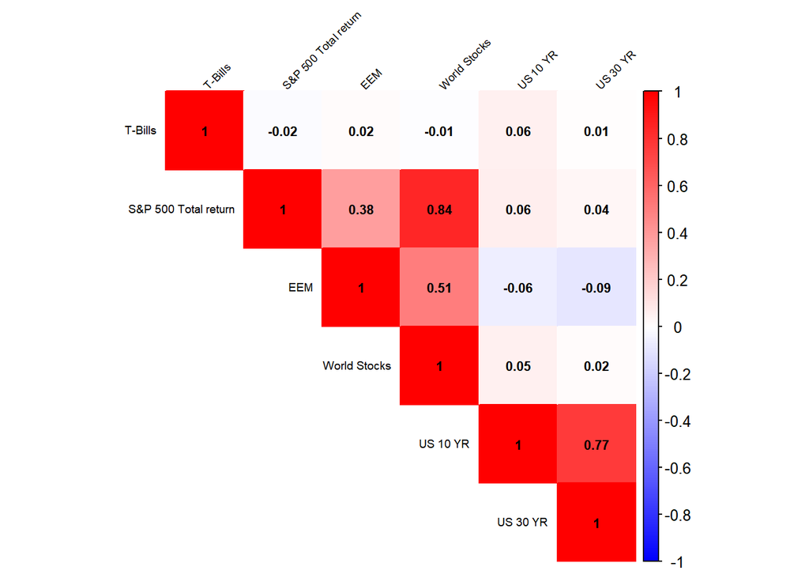

1970년부터의 상관계수들과 비슷한 경향성을 보입니다. 1926년부터로 기간을 늘릴 때 차이가 나는 점은 S&P 500 지수와 신흥국 지수의 상관계수가 0.38로 1970년부터의 상관계수 값에 비해 많이 낮아졌다는 것입니다. 이는 점점 신흥국 경제와 주가 지수가 미국을 비롯한 전세계의 영향을 받게 되어 상관관계가 높아진 것으로 생각해볼 수 있습니다. 1926년부터의 상관계수 데이터, 1970년부터의 상관계수 데이터로 추론해 볼 때, 주식과 국채를 기반으로 자산을 배분하고, 약간의 현금을 가지고 있는 것은 상관계수가 낮은 자산군으로 포트폴리오를 구성함으로써 구조적으로 변동성을 낮출 수 있을 것입니다. 기간별로 볼 때, S&P 500 지수는 대공황이 있던 1920년대 후반 ~ 1930년대 초반, 오일쇼크가 있던 1973 ~ 1974년, 1990년대 후반 ~ 2000년대 초반, 2007 ~ 2008년에 부진했습니다. 선진국 주식은 1973 ~ 1974년, 1990년대 후반 ~ 2000년대 초반, 2007 ~ 2008년, 2011년에 부진했습니다. 신흥국 주식은 대공황이 있던 1920년대 후반 ~ 1930년대 초반, 1930년대 후반, 1940년대 후반, 1990년대 후반, 2008년에 부진했습니다. 미국 주식이나 선진국 주식과 달리, 원자재가 수출에서 차지하는 비중이 높은 신흥국 주식은 1970년대에 그리 나쁘지 않았습니다. 따라서, 특정 기간에 전략이 부진한 결과를 내는 것을 방지하려면 국가 분산도 필요하다고 할 수 있습니다.

# 3. 자산배분 전략

## 3.1. S&P500 - 미국 국채 10년/30년

이제, 가장 높은 수익을 올리는 것으로 알려져 있는 미국 주식 시장에 대한 투자 성과를 개선해 보겠습니다. 주식에 대한 위험을 분산하기 위해 선택하는 대표적인 자산은 국채입니다. 역사적으로 상관관계가 매우 낮았기 때문에 타당한 분산 방식이라고 할 수 있습니다. 가장 흔히 쓰이는 비중은 주식 6 : 국채 4입니다.

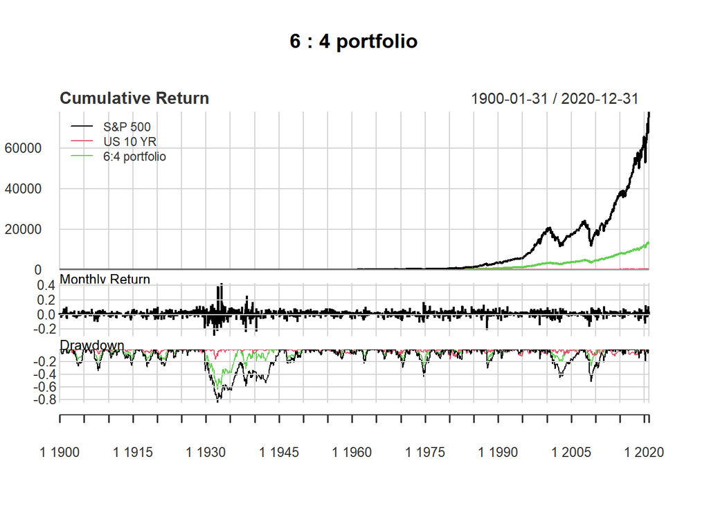

```r
port_SP10_64 = Return.portfolio(R = rets_SP10, weights = c(0.6, 0.4), rebalance_on = 'years')
SP10_64 = cbind(rets_SP10, port_SP10_64) %>% setNames(c('S&P 500', 'US 10 YR', '6:4 portfolio'))
charts.PerformanceSummary(SP10_64, main = '6 : 4 portfolio')
```

```r
Return.cumulative(port_SP10_64)
Return.annualized(port_SP10_64)
Return.cumulative(rets_SP10)
Return.annualized(rets_SP10)

StdDev.annualized(port_SP10_64)
StdDev.annualized(rets_SP10)

SharpeRatio.annualized(port_SP10_64, Rf = ReturnTimeSeries$`T-Bills`, geometric = TRUE)
SharpeRatio.annualized(rets_SP10, Rf = ReturnTimeSeries$`T-Bills`, geometric = TRUE)

maxDrawdown(port_SP10_64)
maxDrawdown(rets_SP10)
```

표 7: S&P500 - 10년 만기 국채 6:4 성과: 1900.01 ~ 2020.12

| 전략 | 누적 수익 | 연복리 수익률 | 표준편차 | 샤프 비율 | 최대 하락폭 |
| --- | --- | --- | --- | --- | --- |
| S&P500 - 10년 만기 국채 6:4 전략 | 14026배 | 8.21% | 10.83% | 0.436 | 63.18% |
| S&P 500 | 77823배 | 9.75% | 17.59% | 0.353 | 83.66% |
| 10년 만기 국채 | 256.9배 | 4.69% | 6.20% | 0.212 | 15.79% |

```
##         From     Trough         To   Depth Length To Trough Recovery
## 1 1929-09-30 1932-05-31 1936-10-31 -0.6318     86        33       53
## 2 1937-03-31 1938-03-31 1943-01-31 -0.3078     71        13       58
## 3 2007-11-30 2009-02-28 2010-09-30 -0.2641     35        16       19
## 4 1973-01-31 1974-09-30 1976-01-31 -0.2634     37        21       16
## 5 1906-10-31 1907-11-30 1908-11-30 -0.2199     26        14       12
```

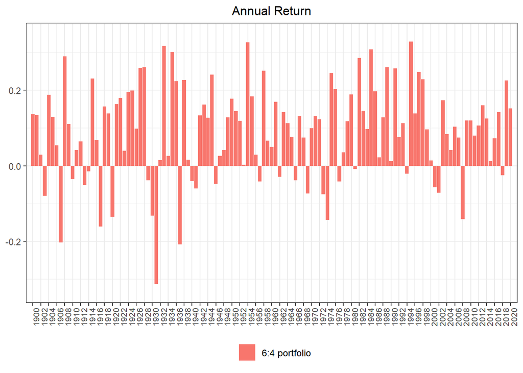

```r
table.Drawdowns(port_SP10_64)
```

S&P 500과 미국 10년 만기 국채를 6:4 비중으로 연간 리밸런싱하는 전략입니다. 1900년 1월부터 누적 수익률은 14026배, 연복리 수익률은 8.21%가 나옵니다. S&P 500 지수의 연복리 수익률 9.75%보다는 낮고, 미국 10년 만기 국채의 4.69%보다는 높습니다. 변동성 기준으로 6:4 전략의 연간 변동성은 10.8%, S&P 500은 17.6%, 미국 10년 만기 국채는 6.2%입니다. 수익률 기준으로 S&P 500보다 조금 낮지만, 변동성이 훨씬 낮은 강점이 있습니다. 위험 대비 수익을 측정하여, 전략의 우수성을 나타낼 수 있는 척도로 샤프 비율을 많이 사용합니다. 연간 샤프 비율이 6:4 전략은 0.436, S&P 500은 0.353, 미국 10년 만기 국채는 0.212입니다. 6:4 전략의 샤프 비율이 S&P 500보다 높으므로, 위험 대비 수익이 더 높은 우수한 전략입니다. 샤프 비율이 높다면 상대적으로 낮은 변동성으로도 비슷한 수익을 만들 수 있기 때문에 저변동성을 유지하여 안정적으로 가거나, 레버리지를 사용해서 S&P 500 수준으로 변동성을 올리고 더 높은 수익을 가져가는 두 가지 선택지를 만들 수 있습니다. 최대 낙폭은 6:4 전략은 63.2%, S&P 500은 83.7%, 미국 10년 만기 국채는 15.8%입니다. 전부 미국 대공황 시기인 1930년대 초반으로, 이 때는 현금 이외의 모든 자산이 외면받던 시기입니다. 그러므로, 항상 시장에 남아 있어야 하는 정적 자산배분 전략에서는 어쩔 수 없는 면이 있습니다. 상위 5개의 낙폭을 보면, 6:4 전략은 대공황 시기를 제외하면 30% 정도가 최대 낙폭이고, 2008년 대침체도 26.4%로 막았습니다. 반면 S&P 500은 2008년 대침체에서 고점 대비 51% 하락했습니다. 데이터상으로 볼 때, 6:4 전략은 수익은 S&P 500보다 못하지만 방어력이 압도적으로 좋은 모습입니다. 10년 만기 국채를 30년 만기 국채로 대체해 보겠습니다.

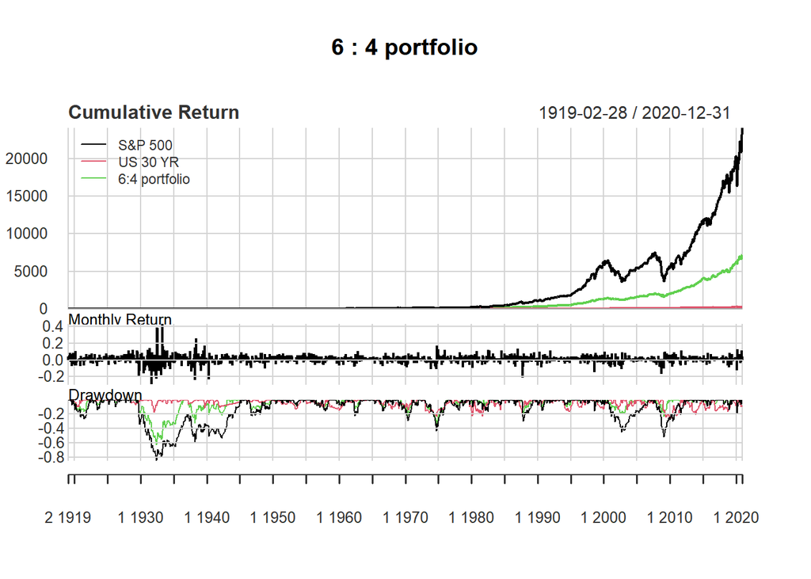

```r
port_SP30_64 = Return.portfolio(R = rets_SP30, weights = c(0.6, 0.4), rebalance_on = 'years')
SP30_64 = cbind(rets_SP30, port_SP30_64) %>% setNames(c('S&P 500', 'US 30 YR', '6:4 portfolio'))
charts.PerformanceSummary(SP30_64, main = '6 : 4 portfolio')
```

```r
Return.cumulative(port_SP30_64)
Return.annualized(port_SP30_64)
Return.cumulative(rets_SP30)
Return.annualized(rets_SP30)

StdDev.annualized(port_SP30_64)
StdDev.annualized(rets_SP30)

SharpeRatio.annualized(port_SP30_64, Rf = ReturnTimeSeries$`T-Bills`[230:1440], geometric = TRUE)
SharpeRatio.annualized(rets_SP30, Rf = ReturnTimeSeries$`T-Bills`[230:1440], geometric = TRUE)

maxDrawdown(port_SP30_64)
maxDrawdown(rets_SP30)
```

표 8: S&P500 - 30년 만기 국채 6:4 성과: 1919.02 ~ 2020.12

| 전략 | 누적 수익 | 연복리 수익률 | 표준편차 | 샤프 비율 | 최대 하락폭 |
| --- | --- | --- | --- | --- | --- |
| S&P500 - 30년 만기 국채 6:4 전략 | 7254배 | 9.11% | 11.78% | 0.469 | 62.16% |
| S&P 500 | 24068배 | 10.41% | 18.46% | 0.367 | 83.66% |
| 30년 만기 국채 | 288.4배 | 5.72% | 9.92% | 0.225 | 25.84% |

```
##         From     Trough         To   Depth Length To Trough Recovery
## 1 1929-09-30 1932-05-31 1936-07-31 -0.6216     83        33       50
## 2 1973-01-31 1974-09-30 1976-06-30 -0.3499     42        21       21
## 3 1937-03-31 1938-03-31 1943-02-28 -0.3226     72        13       59
## 4 2007-11-30 2009-02-28 2010-03-31 -0.2256     29        16       13
## 5 1968-12-31 1970-06-30 1971-01-31 -0.2100     26        19        7
```

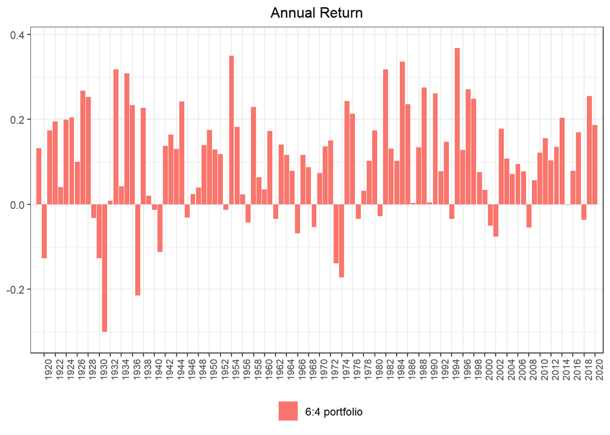

```r
table.Drawdowns(port_SP30_64)
```

1919년 2월부터 누적 수익률 7254배, 연복리 수익률 9.11%, 연간 변동성 11.78%를 기록했습니다. 샤프 비율은 0.469입니다. 최대 낙폭은 62.2% 수준이고, 그 다음 낙폭은 35% 정도입니다. 동 기간 S&P 500은 연복리 수익률 10.4%, 연간 변동성 18.46%, 샤프 비율 0.367, 최대 낙폭 83.66%를 기록했습니다. 연 수익률 9% 수준으로 수익률도 그리 포기하지 않으면서 변동성은 대폭 줄어들어 간단하지만 쓸만한 전략입니다. 데이터의 한계로 테스트 기간이 달라졌으나, 10년 만기 국채로 6:4 전략을 구사했을 때의 샤프 비율 0.436보다 상당히 개선되었습니다.

주식 시장의 리스크를 국채에 분산 투자하여 줄이는 방법을 보았습니다. 주식 시장에 문제가 있을 때, 상관관계가 낮은 자산인 국채를 같이 가지고 있으면 수익을 약간 포기하는 대신 변동성이 크게 줄어듭니다. 변동성을 극도로 보수적으로 관리하겠다면 어쩔 수 없지만, 수익을 극대화하기 위해서는 어느 정도의 변동성은 감수해야 합니다. 그러기 위해서는 두 가지 방식이 있습니다. 첫째로, 바벨 전략입니다. 주식-국채 분산 전략과 달리 변동성도 크고 수익도 주식 시장보다 큰 전략을 동시에 운용할 수 있습니다. 이 고변동성 고수익 전략은 다른 장에서 보겠습니다. 둘째로, 이 전략의 변동성을 올리는 것입니다. 주식-국채 분산 전략의 샤프 비율이 높기 때문에 주식 시장보다 낮은 변동성으로도 비슷한 수준의 수익을 낼 수 있습니다. 변동성을 올리기 위해서는 10년 만기 국채를 만기가 더 긴 30년 만기 국채로 교체하거나, 아예 레버리지를 직접 사용할 수 있습니다. 편입 자산군과 전략 틀이 확정되면 레버리지를 사용하여 목표 변동성을 설정한 뒤 백테스트를 해 보겠습니다.

이제 주식-국채 자산배분 전략의 약점 중 보완할 수 있는 것을 찾아보도록 하겠습니다. 앞서 테스트한 자산배분 전략들이 공통적으로 부진한 시기는 1906 ~ 1908년, 1929 ~ 1936년, 1937 ~ 1943년, 1973 ~ 1976년, 2007 ~ 2010년입니다.

1906 ~ 1908년 시기에는 1907년 공황이 있었습니다. 대공황 이전 최대의 공황으로 손꼽히는 시기였습니다. 이 시기에는 금융 기관들의 보유 지급 준비금이 너무 낮고 시장 규제 체제가 미비해 레버리지를 동원한 주가 조작이 성행했습니다. 주가 조작 실패에 대한 시장 불안으로 뱅크런 사태가 일어났고, 니커보커의 파산으로 공황이 본격적으로 일어났습니다. 공황 동안 주식 시장은 최대 34%, 10년 만기 미국 국채는 3.6%, 6:4 전략은 22%가 하락했습니다.

1929 ~ 1936년 시기는 대공황 시기와 이후 회복기입니다. 대공황은 1차 대전 이후의 1920년대 호황에서의 거품이 꺼지고, 1929년 10월 주가 대폭락으로 본격적으로 진행되었습니다. 독일은 이 시기에 1차 대전 여파로 인한 하이퍼 인플레이션으로 고생했고, 유럽 전역으로 위기가 확산되는 등 전세계가 공황에 빠졌습니다. 이 시기에 주식 시장은 84% 하락을 경험했고, 10년 만기 국채는 15% 하락을 경험했습니다. 6:4 전략은 최대 63% 하락을 겪었습니다.

1937 ~ 1943년 시기는 2차 대전과 겹치는 시기입니다. 미국은 1937년에 연방준비제도가 대공황이 끝났다고 생각해 기준금리를 급하게 올렸고, 이것이 주식 시장 폭락을 가져왔습니다. 1937년 3월 ~ 1938년 3월 기간 동안 49.8% 하락했습니다. 같은 기간 10년 만기 국채는 4.1% 올랐고, 6:4 전략은 최대 31% 하락을 겪었습니다. 본격적인 2차 대전 기간 동안은 6:4 전략도 하락한 해가 있었으나, 미국은 처음부터 참전했던 것은 아니었고 본토의 피해도 거의 없었기 때문에 약간의 조정만 겪었습니다.

1973 ~ 1976년 시기는 오일 쇼크가 있던 시기입니다. 중동 전쟁의 과정에서 산유국들은 석유 감산을 했고, 전쟁이라는 리스크에 공급 부족으로 유가가 폭등했습니다. 미국은 베트남 전쟁이 끝난지 얼마 되지 않아 전쟁 비용을 충당하기 위해 적자 재정을 펼치고, 금태환제를 깨는 등 경기 상황이 매우 좋지 않았는데 유가 급등으로 물가가 치솟아 어쩔 수 없이 연준은 금리를 올렸습니다. 이 금리 상승은 주식과 국채 모두 부진한 수익을 거두게 했습니다. 이 기간 동안 주식 시장은 최대 42%, 6:4 전략은 26% 하락을 경험했습니다.

1979 ~ 1981년에도 2차 오일쇼크가 있었으나, 1차 쇼크와는 달리 IT와 원자재 기업들은 잘 버텨냈고, 오히려 인플레이션을 잡기 위한 급격한 금리 상승으로 국채 수익률이 부진했습니다. 6:4 전략은 최대 11% 정도 하락으로 끝났습니다.

2007 ~ 2010년 시기는 익숙한 2008년 금융위기가 있던 시기입니다. 주식 시장은 최대 -51%의 하락을 경험했고, 6:4 전략은 국채의 방어력으로 -26% 하락으로 막아냈습니다. 6:4 전략 등 주식-국채로만 만든 자산배분 전략은 시장을 넘어서는 국가 전체의 혼란과 인플레이션 두 가지에 의해 크게 흔들립니다. 시장을 넘어서는 국가 전체의 혼란은 전략 자체의 방어 기능을 추가하여 시장 상황이 좋지 않으면 시장 노출 비중을 크게 줄이도록 설계할 수 있습니다. 이런 방식은 동적 자산배분의 일종으로, 다른 장에서 보겠습니다. 인플레이션에 대응하려면 자산배분 전략에 주식과 국채와는 인플레이션에 다르게 반응하는 자산들을 추가해야 합니다. 인플레이션에 강한 자산으로는 금, 원자재, TIPS, REITs 등이 알려져 있고, 이들 자산군을 전략에 편입하는 것을 생각해 볼 수 있습니다. 정적 자산배분의 관점에서 저 자산군을 편입하기 위한 논의를 하겠습니다.

## 3.2. 유대인 전략

유대인들이 만든 전략으로, 수천년 전에 쓰여진 탈무드에 등장합니다. 자산을 3등분하여 토지(부동산), 사업(주식), 여유 자금(현금)으로 가지고 있으라는 것입니다. 전략에서 현금을 보유하기 때문에 변동성이 낮아질 것으로 보입니다. S&P 500 지수, NA REIT(북미 리츠), T-Bill (단기 국채) 세 가지 자산군으로 테스트하겠습니다.

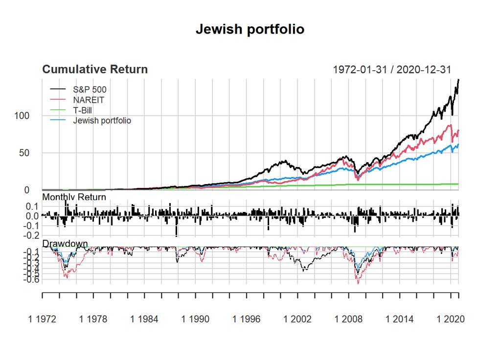

```r
# 유대인 --> 주식 : 리츠 : 현금 1 : 1 : 1
port_JEW = Return.portfolio(R = rets_JEW, weights = c(1/3, 1/3, 1/3), rebalance_on = 'years')
JEW = cbind(rets_JEW, port_JEW) %>% setNames(c('S&P 500', 'NAREIT', 'T-Bill', 'Jewish portfolio'))
charts.PerformanceSummary(JEW, main = 'Jewish portfolio')
```

```r
Return.cumulative(port_JEW)
Return.annualized(port_JEW)
Return.cumulative(rets_JEW)
Return.annualized(rets_JEW)

StdDev.annualized(port_JEW)
StdDev.annualized(rets_JEW)

SharpeRatio.annualized(port_JEW, Rf = rets_JEW$T.Bills, geometric = TRUE)
SharpeRatio.annualized(rets_JEW, Rf = rets_JEW$T.Bills, geometric = TRUE)

maxDrawdown(port_JEW)
maxDrawdown(rets_JEW)
```

표 9: 유대인 전략 성과: 1972.01 ~ 2020.12

| 전략 | 누적 수익 | 연복리 수익률 | 표준편차 | 샤프 비율 | 최대 하락폭 |
| --- | --- | --- | --- | --- | --- |
| 유대인 전략 | 63.71배 | 8.85% | 9.67% | 0.419 | 41.39% |
| S&P 500 | 150.8배 | 10.78% | 15.25% | 0.387 | 50.95% |
| 리츠 | 82.64배 | 9.43% | 17.52% | 0.262 | 67.88% |
| 현금 | 9.12배 | 4.61% | 0.99% | 0 | 0 |

```r
table.Drawdowns(port_JEW)
```

```
##         From     Trough         To   Depth Length To Trough Recovery
## 1 2007-06-30 2009-02-28 2011-04-30 -0.4139     47        21       26
## 2 1973-01-31 1974-09-30 1976-06-30 -0.2972     42        21       21
## 3 1987-09-30 1987-11-30 1989-01-31 -0.1599     17         3       14
## 4 2020-02-28 2020-03-31 2020-11-30 -0.1535     10         2        8
## 5 2011-05-31 2011-09-30 2012-02-29 -0.1117     10         5        5
```

```r
cor(subset(ReturnData, select=c('S&P 500 Total return', 'NAREIT')), use='complete.obs')
```

```
##                      S&P 500 Total return    NAREIT
## S&P 500 Total return            1.0000000 0.6047905
## NAREIT                          0.6047905 1.0000000
```

유대인 자산배분 전략은 1972년부터 누적 수익률 63.7배, 연복리 수익률 8.85%로 준수합니다. 같은 기간 S&P 500은 연 10.78%, 리츠는 연 9.43% 수익을 냈습니다. 변동성은 유대인 전략이 연 9.67%, S&P 500은 15.25%, 리츠는 연 17.52%로 유대인 전략은 수익을 약간 희생하지만 변동성을 크게 낮추는 전략입니다. 샤프 비율에서도 유대인 전략은 0.419, S&P 500은 0.387, 리츠는 0.262으로 위험 대비 수익 기준으로 괜찮은 전략입니다. 수천년 전에 나온 전략인데도 불구하고, 꽤 잘 작동합니다. 이 전략의 결함은 최대 낙폭입니다. 2007년 6월 ~ 2009년 2월까지 41.4% 하락을 경험했습니다. 변동성도 낮고 위험 대비 수익도 괜찮으나, 40%가 넘는 하락은 좋지 않습니다. 분산투자를 했는데 하락폭이 이렇게 큰 이유는 상관관계 때문입니다. 1972년부터 S&P 500과 리츠는 0.605의 상관관계를 가지고 있습니다. 상관계수가 꽤 높으므로 다른 자산군이지만 분산 효과는 미미합니다. 자산군 분산 전략은 상관관계가 작은 자산들로 구현할 때 원래의 의도대로 작동할 것입니다.

## 3.3. Harry Brown 영구 포트폴리오

비교적 간단한 전략을 먼저 보겠습니다. Harry Brown이라는 사람이 만든 영구 포트폴리오라는 것입니다. 주식 25%, 장기 국채 25%, 금 25%, 현금 25%를 가져가는 전략입니다. 전략의 논리는 주식의 위험을 장기 국채로 낮추고, 고인플레이션 시기에 주식과 국채가 부진할 때 금이 대안으로 들어가 있고, 대공황과 같은 현금이 왕이 되는 최악의 상황을 위해 현금을 가지고 간다는 것입니다. 현금 비중이 있기 때문에 변동성은 낮을 수밖에 없는 전략이고, 국채, 금, 현금 모두 주식보다는 장기적인 수익률은 부족하므로 위험 대비 수익이 주식 시장보다 높게 나온다면 괜찮은 전략일 것입니다.

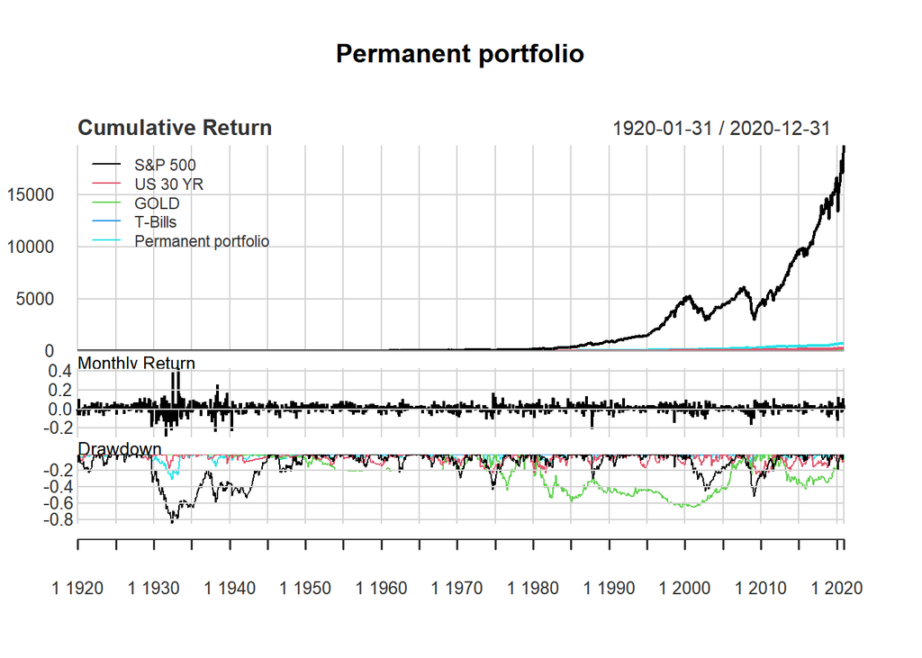

```r
# 영구 --> 주식 : 장기국채 : 금 : 현금 1 : 1 : 1 : 1
port_Permanent = Return.portfolio(R = rets_Permanent, weights = c(1/4, 1/4, 1/4, 1/4), rebalance_on = 'years')
Permanent = cbind(rets_Permanent, port_Permanent) %>% setNames(c('S&P 500', 'US 30 YR', 'GOLD', 'T-Bills',
                                                                 'Permanent portfolio'))

charts.PerformanceSummary(Permanent, main = 'Permanent portfolio')
```

```r
Return.cumulative(port_Permanent)
Return.annualized(port_Permanent)
Return.cumulative(rets_Permanent)
Return.annualized(rets_Permanent)

StdDev.annualized(port_Permanent)
StdDev.annualized(rets_Permanent)

SharpeRatio.annualized(port_Permanent, Rf = rets_Permanent$T.Bills, geometric = TRUE)
SharpeRatio.annualized(rets_Permanent, Rf = rets_Permanent$T.Bills, geometric = TRUE)

maxDrawdown(port_Permanent)
maxDrawdown(rets_Permanent)
```

표 10: Harry Brown 영구 포트폴리오 성과: 1920.01 ~ 2020.12

| 전략 | 누적 수익 | 연복리 수익률 | 표준편차 | 샤프 비율 | 최대 하락폭 |
| --- | --- | --- | --- | --- | --- |
| Harry Brown 영구 포트폴리오 | 773배 | 6.81% | 6.60% | 0.496 | 30.21% |
| S&P 500 | 19737배 | 10.29% | 18.46% | 0.360 | 83.66% |
| 30년 만기 국채 | 288배 | 5.77% | 9.96% | 0.227 | 25.84% |
| GOLD | 91.8배 | 4.58% | 14.60% | 0.08 | 64.97% |
| 현금(T-Bill) | 30.0배 | 3.42% | 0.85% | 0 | 0 |

```
##         From     Trough         To   Depth Length To Trough Recovery
## 1 1929-09-30 1932-05-31 1933-11-30 -0.3021     51        33       18
## 2 1937-03-31 1938-03-31 1942-12-31 -0.1428     70        13       57
## 3 1974-04-30 1974-09-30 1974-12-31 -0.1209      9         6        3
## 4 1969-06-30 1970-06-30 1971-01-31 -0.1201     20        13        7
## 5 2008-03-31 2008-10-31 2008-12-31 -0.1189     10         8        2
```

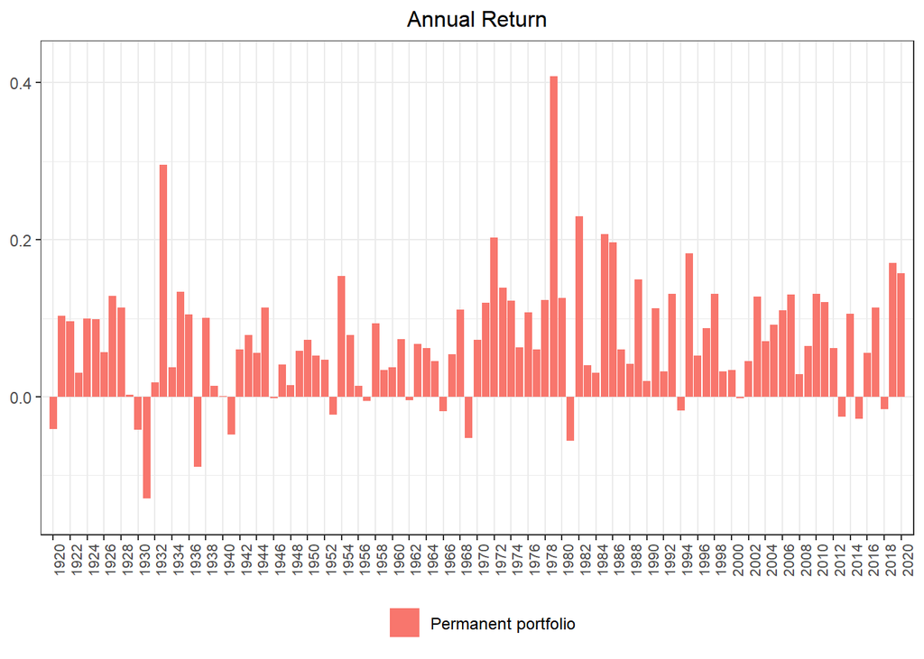

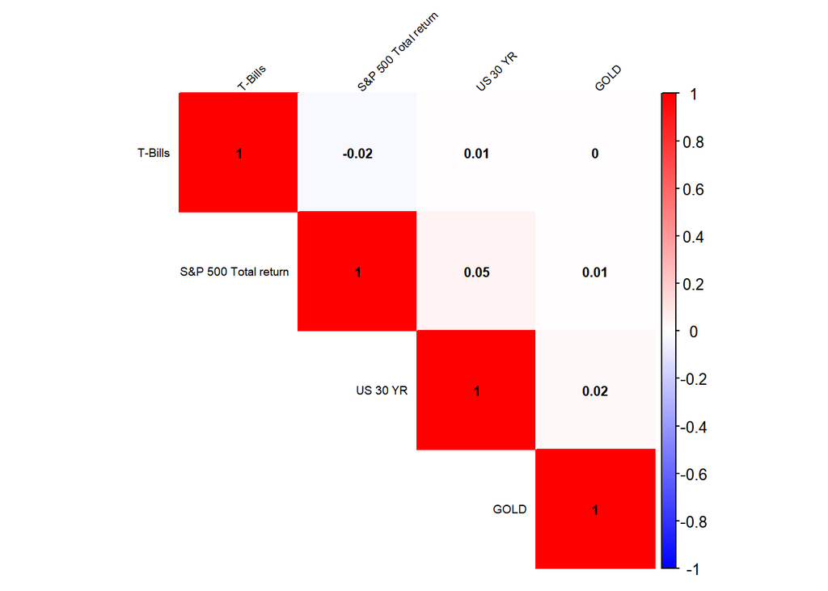

```r
table.Drawdowns(port_Permanent)
```

영구 포트폴리오는 1920년부터 누적 수익률 773배, 연복리 수익률 6.80%를 기록했습니다. 같은 기간 S&P 500은 연 10.29%를 기록해 수익률에서는 다소 모자라 보입니다. 연간 변동성에서는 영구 포트폴리오는 6.60%, S&P 500은 18.46%를 기록하여 변동성이 1/3로 매우 견고한 전략입니다. 위험 대비 수익인 샤프 비율도 영구 포트폴리오가 0.496, S&P 500이 0.360으로 영구 포트폴리오가 더 좋습니다. 최대 낙폭도 대공황 시기만 30% 수준이고, 나머지는 15% 이하로 막아냅니다. 따라서, 위험을 감수할 생각이 전혀 없으며 전략을 매우 긴 시간 유지할 수 있고, 연 6% 수준의 수익이 필요하다면 훌륭한 전략입니다. 장기 상관관계로 보아도 전략의 구성 자산인 주식, 국채, 금, 현금이 상관관계가 거의 0입니다. 자산배분 전략은 상관관계가 낮은 우상향하는 자산에 분산 투자하는 것이므로, Harry Brown의 영구 포트폴리오는 그 목적에 적합합니다. 이후 나올 전략들도 주식, 국채, 금을 기반으로 움직이는 전략들입니다.

## 3.4. Tyler - Golden Butterfly (황금나비)

영구 포트폴리오만 가지고도 자산배분 전략에서는 매우 안정적입니다. 그러나, 안정성만이 아니라 수익성도 생각해야 합니다. Portfoliochart라는 사이트를 운영하는 Tyler라는 사람은 Golden Butterfly, 일명 황금나비 전략을 제안했습니다. 영구 포트폴리오를 일부 수정한 전략으로, 한쪽 날개는 주식, 한쪽 날개는 채권, 가운데는 금이 있는 것이 나비처럼 보여 저렇게 이름을 붙였다 합니다. 구성은 주가지수 20%, 소형 가치주 20%, 장기국채 20%, 단기국채 20%, 금 20%입니다. 영구 포트폴리오의 기본 틀은 유지하면서 변동성과 수익률을 높게 가져가는 전략일 것이고, 데이터로 보겠습니다.

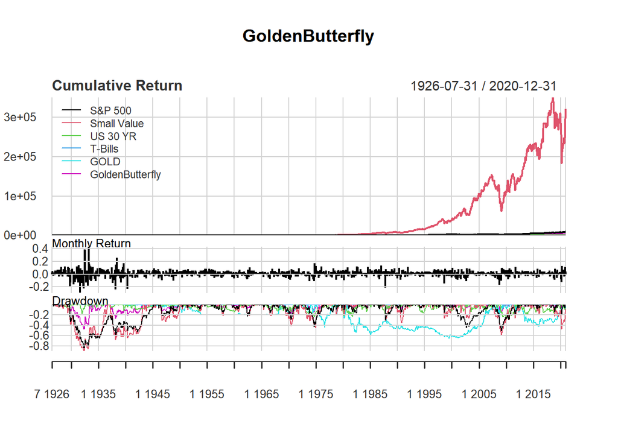

```r
# 황금나비: 주가지수 : 소형가치주 : 장기국채 : 단기국채 : 금 = 1 : 1 : 1 : 1 : 1
port_GoldenButterfly = Return.portfolio(R = rets_GoldenButterfly, weights = c(1/5, 1/5, 1/5, 1/5, 1/5),
                                        rebalance_on = 'years')

GoldenButterfly = cbind(rets_GoldenButterfly, port_GoldenButterfly) %>%
  setNames(c('S&P 500', 'Small Value', 'US 30 YR', 'T-Bills', 'GOLD', 'GoldenButterfly'))

charts.PerformanceSummary(GoldenButterfly, main = 'GoldenButterfly')
```

```r
Return.cumulative(port_GoldenButterfly)
Return.annualized(port_GoldenButterfly)
Return.cumulative(rets_GoldenButterfly)
Return.annualized(rets_GoldenButterfly)

StdDev.annualized(port_GoldenButterfly)
StdDev.annualized(rets_GoldenButterfly)

SharpeRatio.annualized(port_GoldenButterfly, Rf = rets_GoldenButterfly$T.Bills, geometric = TRUE)
SharpeRatio.annualized(rets_GoldenButterfly, Rf = rets_GoldenButterfly$T.Bills, geometric = TRUE)

maxDrawdown(port_GoldenButterfly)
maxDrawdown(rets_GoldenButterfly)
```

표 11: Golden Butterfly 성과: 1926.07 ~ 2020.12

| 전략 | 누적 수익 | 연복리 수익률 | 표준편차 | 샤프 비율 | 최대 하락폭 |
| --- | --- | --- | --- | --- | --- |
| Golden Butterfly | 3134배 | 8.89% | 10.01% | 0.532 | 47.40% |
| S&P 500 | 9995배 | 10.24% | 18.75% | 0.353 | 83.66% |
| Small Value | 321732배 | 14.36% | 28.22% | 0.377 | 88.82% |
| US 30 YR | 176배 | 5.63% | 10.21% | 0.212 | 25.84% |
| GOLD | 91.8배 | 4.90% | 15.09% | 0.096 | 64.97% |
| 현금(T-Bill) | 23.3배 | 3.39% | 0.88% | 0 | 0 |

```
##         From     Trough         To   Depth Length To Trough Recovery
## 1 1929-09-30 1932-05-31 1933-06-30 -0.4740     46        33       13
## 2 1937-03-31 1938-03-31 1943-02-28 -0.2739     72        13       59
## 3 1969-06-30 1970-06-30 1971-01-31 -0.1740     20        13        7
## 4 2008-02-29 2009-02-28 2009-09-30 -0.1540     20        13        7
## 5 1974-04-30 1974-09-30 1975-01-31 -0.1498     10         6        4
```

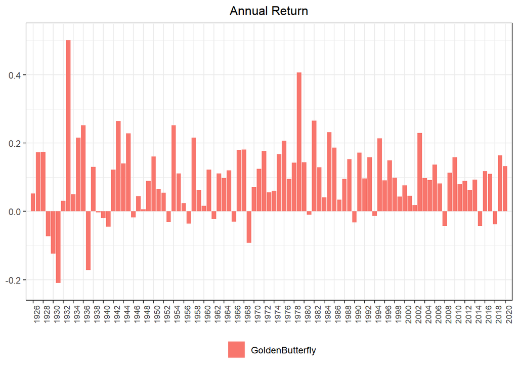

```r
table.Drawdowns(port_GoldenButterfly)
```

1926년 7월부터 누적 수익률 3134배, 연복리 수익률 8.89%, 연간 변동성 10%로 수익률도 변동성도 영구 포트폴리오보다 높습니다. 샤프 비율 0.532로 0.5를 넘는 전략이 나타났습니다. 한 가지 결함은 최대 낙폭입니다. 소형 가치주가 연복리 14.36%라는 압도적인 수익을 내지만(차트 상에서도 나타납니다) 대공황 시기에 89% 하락을 경험하는데, 이 때문에 Golden Butterfly 전략도 대공황 시기 최대 낙폭이 47.4%나 됩니다. 대공황 시기에는 현금을 제외하고는 모든 자산군이 부진했으니 논외로 한다면 1937년 3월부터 1938년 3월까지의 27.4% 하락이 그 다음입니다.

## 3.5. Ray Dalio & Tony Robbins - All Seasons

위험 균형 전략의 1세대이고, 세계 최대의 헤지펀드 중 하나인 Bridgewater Associates의 설립자 Ray Dalio는 Tony Robbins의 Money 라는 책에서 초보 투자자들을 위한 다각화가 잘 된 자산배분 전략을 추천했습니다. All Seasons 포트폴리오라고도 불리고, 비중은 주식 30%, 중기 국채 15%, 장기 국채 40%, 금 7.5%, 원자재 7.5%를 보유합니다. 금과 원자재가 들어갔으니 인플레이션에 대한 방어는 잘 될 것으로 보이고, 주식 비중이 낮아져서 수익률은 약간 낮아질 것처럼 보이는 전략입니다.

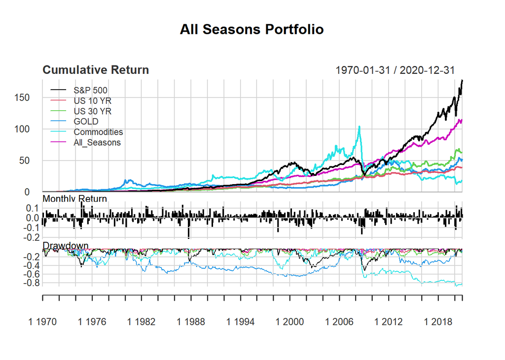

```r
port_All_Seasons = Return.portfolio(R = rets_All_Seasons, weights = c(0.3, 0.15, 0.4, 0.075, 0.075),
                                    rebalance_on = 'years')

All_Seasons = cbind(rets_All_Seasons, port_All_Seasons) %>% setNames(c('S&P 500', 'US 10 YR', 'US 30 YR', 'GOLD',
                                                                       'Commodities', 'All_Seasons'))

charts.PerformanceSummary(All_Seasons, main = 'All Seasons Portfolio')
```

```r
Return.cumulative(port_All_Seasons)
Return.annualized(port_All_Seasons)
Return.cumulative(rets_All_Seasons)
Return.annualized(rets_All_Seasons)

StdDev.annualized(port_All_Seasons)
StdDev.annualized(rets_All_Seasons)

SharpeRatio.annualized(port_All_Seasons, Rf = ReturnTimeSeries$`T-Bills`[841:1452], geometric = TRUE)
SharpeRatio.annualized(rets_All_Seasons, Rf = ReturnTimeSeries$`T-Bills`[841:1452], geometric = TRUE)

maxDrawdown(port_All_Seasons)
maxDrawdown(rets_All_Seasons)
```

표 12: All Seasons 성과: 1970.01 ~ 2020.12

| 전략 | 누적 수익 | 연복리 수익률 | 표준편차 | 샤프 비율 | 최대 하락폭 |
| --- | --- | --- | --- | --- | --- |
| All Seasons | 116.2배 | 9.77% | 8.22% | 0.597 | 13.32% |
| S&P 500 | 179.3배 | 10.71% | 15.30% | 0.379 | 50.95% |
| US 10 YR | 39.7배 | 7.49% | 8.17% | 0.333 | 15.79% |
| US 30 YR | 63.3배 | 8.47% | 12.74% | 0.287 | 25.84% |
| GOLD | 53.6배 | 8.12% | 19.74% | 0.167 | 64.97% |
| GSCI | 19.8배 | 6.03% | 20.31% | 0.065 | 80.90% |

```
##         From     Trough         To   Depth Length To Trough Recovery
## 1 2009-01-31 2009-02-28 2009-11-30 -0.1332     11         2        9
## 2 1980-12-31 1981-09-30 1982-08-31 -0.1305     21        10       11
## 3 1974-03-31 1974-09-30 1975-02-28 -0.1218     12         7        5
## 4 2008-07-31 2008-10-31 2008-12-31 -0.1114      6         4        2
## 5 1980-02-29 1980-03-31 1980-05-31 -0.1053      4         2        2
```

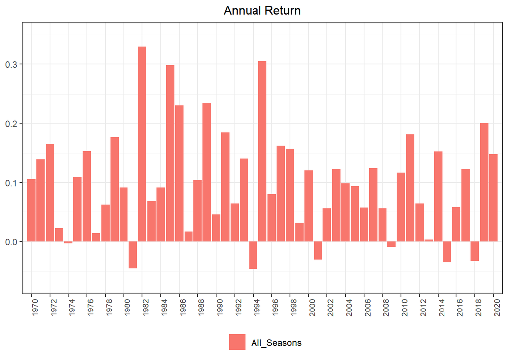

```r
table.Drawdowns(port_All_Seasons)
```

원자재 지수인 GSCI가 1970년부터 존재하므로, 1970년 1월부터의 테스트입니다. 테스트 기간이 다소 짧아지기는 했지만, 인플레이션에 대한 대응의 문제로 6:4 전략 등 전통적인 주식-국채 자산배분 전략을 업그레이드 하게 된 것이므로 심각한 인플레이션이 있던 70년대와 80년대 초반을 포함하므로 괜찮다고 생각합니다. 4계절 전략은 1970년 1월부터 누적 수익률 116.2배, 연복리 수익률 9.77%, 연간 변동성 8.22%, 샤프 지수 0.597, 최대 낙폭 13.3%라는 성과를 냅니다. 기존 6:4 전략이 인플레이션이 심했던 1차 오일쇼크 시기(1973 ~ 1976년) 최대 26% 하락을 경험했으나, 4계절 전략은 최대 12% 하락으로 막아냅니다. 주식-국채 자산배분의 기본 틀은 유지하면서 주식 시장의 위험을 방어하고, 주식-국채가 둘 다 부진하게 되는 고인플레이션 시기를 금과 원자재로 방어하는 식으로 전략을 구조적으로 개선시켰습니다. 원자재를 금으로 대체하여 더 먼 과거에도 저런 사프 지수를 낼 수 있는지 보겠습니다.

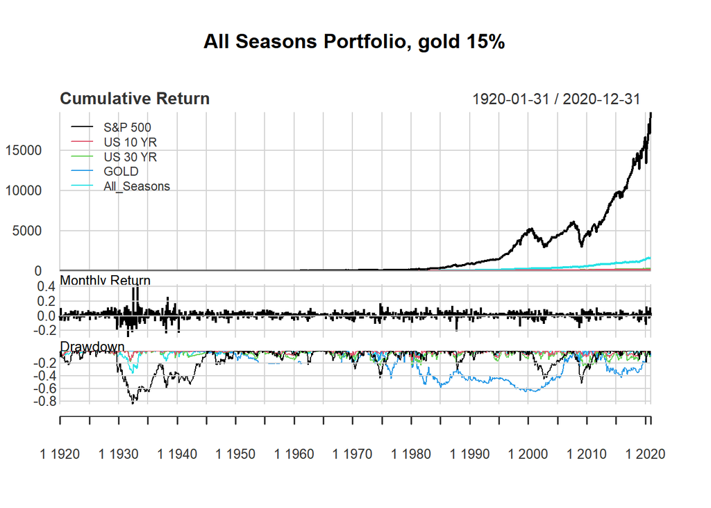

```r
port_All_Seasons_2 = Return.portfolio(R = rets_All_Seasons_2, weights = c(0.3, 0.15, 0.4, 0.15),
                                    rebalance_on = 'years')
All_Seasons_2 = cbind(rets_All_Seasons_2, port_All_Seasons_2) %>% setNames(c('S&P 500', 'US 10 YR', 'US 30 YR', 'GOLD',
                                                                             'All_Seasons'))

charts.PerformanceSummary(All_Seasons_2, main = 'All Seasons Portfolio, gold 15%')
```

```r
Return.cumulative(port_All_Seasons_2)
Return.annualized(port_All_Seasons_2)
Return.cumulative(rets_All_Seasons_2)
Return.annualized(rets_All_Seasons_2)

StdDev.annualized(port_All_Seasons_2)
StdDev.annualized(rets_All_Seasons_2)

SharpeRatio.annualized(port_All_Seasons_2, Rf = ReturnTimeSeries$`T-Bills`[241:1452], geometric = TRUE)
SharpeRatio.annualized(rets_All_Seasons_2, Rf = ReturnTimeSeries$`T-Bills`[241:1452], geometric = TRUE)

maxDrawdown(port_All_Seasons_2)
maxDrawdown(rets_All_Seasons_2)
```

표 13: All Seasons (Gold 15%) 성과: 1920.01 ~ 2020.12

| 전략 | 누적 수익 | 연복리 수익률 | 표준편차 | 샤프 비율 | 최대 하락폭 |
| --- | --- | --- | --- | --- | --- |
| All Seasons | 1661배 | 7.62% | 7.85% | 0.517 | 35.72% |
| S&P 500 | 19737배 | 10.29% | 18.46% | 0.360 | 83.66% |
| US 10 YR | 174배 | 5.24% | 6.65% | 0.264 | 15.79% |
| US 30 YR | 288배 | 5.77% | 9.96% | 0.227 | 25.84% |
| GOLD | 91.8배 | 4.58% | 14.60% | 0.076 | 64.97% |

```
##         From     Trough         To   Depth Length To Trough Recovery
## 1 1929-09-30 1932-05-31 1934-02-28 -0.3572     54        33       21
## 2 1937-03-31 1938-03-31 1939-05-31 -0.1660     27        13       14
## 3 1969-06-30 1970-06-30 1970-12-31 -0.1506     19        13        6
## 4 1974-04-30 1974-09-30 1975-01-31 -0.1470     10         6        4
## 5 1980-07-31 1981-09-30 1982-08-31 -0.1391     26        15       11
```

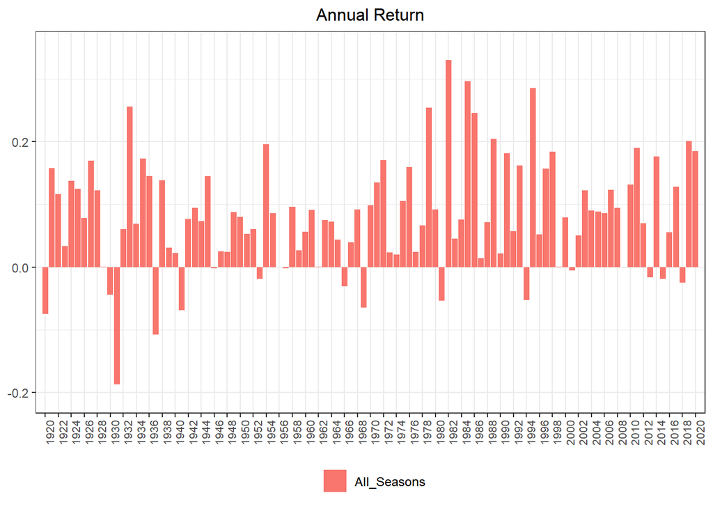

```r
table.Drawdowns(port_All_Seasons_2)
```

1920년부터로 늘렸습니다. 누적 수익률 1661.4배, 연복리 수익률 7.62%, 연간 변동성 7.85%, 샤프 비율 0.517로 여전히 안정적이며 황금나비 전략과 함께 샤프 비율 0.5를 넘습니다. 최대 낙폭은 대공황 시절의 -35.7%로 Golden Butterfly(황금나비) 전략보다는 안정적입니다. 지금까지 테스트한 정적 자산배분 전략 중에서는 올시즌스와 황금나비 전략이 가장 좋아 보입니다.

## 3.6. 전략 개선 - GoldenButterfly

이 전략들에 대해서도 약점을 찾고, 개선할 방법을 찾아야 합니다. 일시적인 기간 또는 특정 경제 사이클에서 좋았다고 해서 그 다음 사이클에서도 좋으리라는 보장은 없습니다. 샤프 비율이 가장 좋았던 두 전략인 올시즌스 전략과 황금나비 전략을 위주로 개선하겠습니다. 황금나비 전략의 첫번째 문제는 주식이 미국에만 집중되어 있는 것입니다. 2000 ~ 2010년까지의 미국 주식은 수익을 올리지 못했습니다. 이런 10년이 다시 오지 않으리라는 법이 없으므로, 대비해야 합니다.

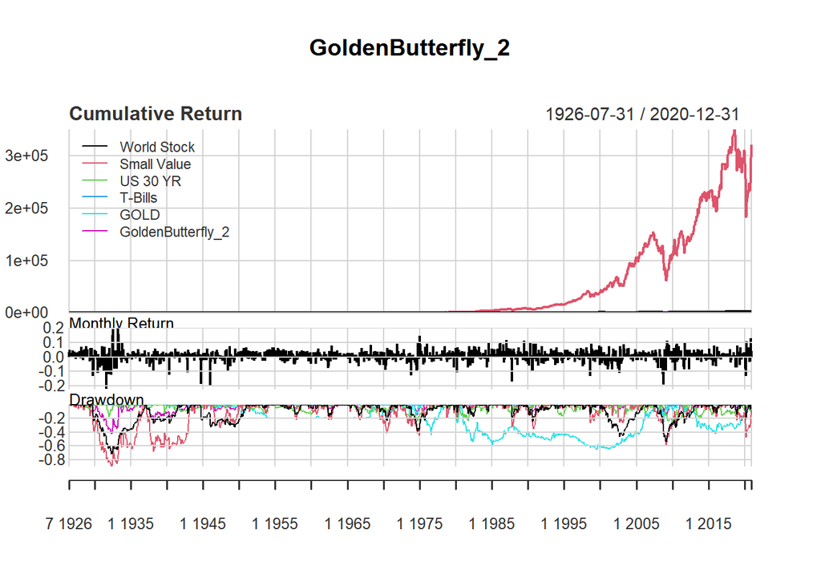

```r
# 황금나비 2 : 전세계 : 소형가치 : 장기국채 : 단기국채 : 금  = 1 : 1 : 1 : 1 : 1
port_GoldenButterfly_2 = Return.portfolio(R = rets_GoldenButterfly_2, weights = c(1/5, 1/5, 1/5, 1/5, 1/5),
                                          rebalance_on = 'years')

GoldenButterfly_2 = cbind(rets_GoldenButterfly_2, port_GoldenButterfly_2) %>%
  setNames(c('World Stock', 'Small Value', 'US 30 YR', 'T-Bills', 'GOLD', 'GoldenButterfly_2'))

charts.PerformanceSummary(GoldenButterfly_2, main = 'GoldenButterfly_2')
```

```r
Return.cumulative(port_GoldenButterfly_2)
Return.annualized(port_GoldenButterfly_2)
Return.cumulative(rets_GoldenButterfly_2)
Return.annualized(rets_GoldenButterfly_2)

StdDev.annualized(port_GoldenButterfly_2)
StdDev.annualized(rets_GoldenButterfly_2)

SharpeRatio.annualized(port_GoldenButterfly_2, Rf = rets_GoldenButterfly_2$T.Bills, geometric = TRUE)
SharpeRatio.annualized(rets_GoldenButterfly_2, Rf = rets_GoldenButterfly_2$T.Bills, geometric = TRUE)

maxDrawdown(port_GoldenButterfly_2)
maxDrawdown(rets_GoldenButterfly_2)
```

표 14: Golden Butterfly_2 (with World Stock) 성과: 1926.07 ~ 2020.12

| 전략 | 누적 수익 | 연복리 수익률 | 표준편차 | 샤프 비율 | 최대 하락폭 |
| --- | --- | --- | --- | --- | --- |
| Golden Butterfly_2 | 2448배 | 8.61% | 9.19% | 0.550 | 42.03% |
| World Stock | 3257배 | 8.94% | 14.50% | 0.370 | 71.33% |
| Small Value | 321732배 | 14.36% | 28.22% | 0.377 | 88.82% |
| US 30 YR | 176배 | 5.63% | 10.21% | 0.212 | 25.84% |
| GOLD | 91.8배 | 4.90% | 15.09% | 0.096 | 64.97% |
| 현금(T-Bill) | 23.3배 | 3.39% | 0.88% | 0 | 0 |

```
##         From     Trough         To   Depth Length To Trough Recovery
## 1 1929-09-30 1932-05-31 1933-06-30 -0.4203     46        33       13
## 2 1937-03-31 1938-03-31 1942-10-31 -0.2240     68        13       55
## 3 1969-06-30 1970-06-30 1971-02-28 -0.1669     21        13        8
## 4 2008-03-31 2009-02-28 2009-09-30 -0.1588     19        12        7
## 5 1974-04-30 1974-09-30 1975-01-31 -0.1475     10         6        4
```

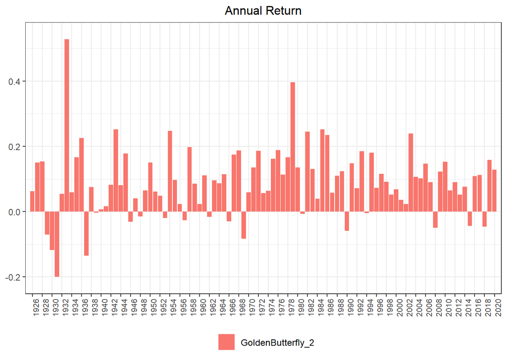

```r
table.Drawdowns(port_GoldenButterfly_2)
```

1926년 7월부터 누적 수익률 2448배, 연복리 수익률 8.61%, 연간 변동성 9.19%, 샤프 비율 0.550으로 개선되었습니다. 최대 낙폭은 대공황 시기의 42%로, 아직 낙폭이 크지만 원래 버전보다는 개선되었습니다. 2차대전 시기의 22.4% 하락 이후로는 20% 이상의 하락을 경험하지 않습니다.

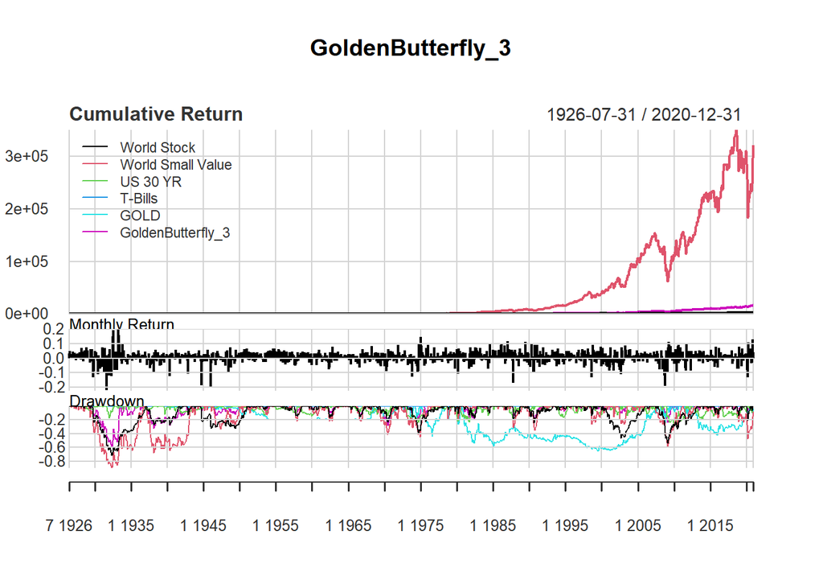

```r
# 황금나비 3 : 전세계주식 : 소형가치 : 장기국채 : 단기국채 : 금  = 1 : 1 : 1 : 1 : 1
port_GoldenButterfly_3 = Return.portfolio(R = rets_GoldenButterfly_3, weights = c(3/10, 3/10, 3/10, -1/5, 3/10),
                                          rebalance_on = 'years')

GoldenButterfly_3 = cbind(rets_GoldenButterfly_3, port_GoldenButterfly_3) %>%
  setNames(c('World Stock', 'World Small Value', 'US 30 YR', 'T-Bills', 'GOLD', 'GoldenButterfly_3'))

charts.PerformanceSummary(GoldenButterfly_3, main = 'GoldenButterfly_3')
```

[output not shown]

표 15: Golden Butterfly_3 (1.5x 차입) 성과: 1926.07 ~ 2020.12

| 전략 | 누적 수익 | 연복리 수익률 | 표준편차 | 샤프 비율 | 최대 하락폭 |
| --- | --- | --- | --- | --- | --- |
| Golden Butterfly_3 | 17088배 | 10.86% | 13.62% | 0.531 | 58.87% |
| World Stock | 3257배 | 8.94% | 14.50% | 0.370 | 71.33% |
| World Small Value | 321732배 | 14.36% | 28.22% | 0.377 | 88.82% |
| US 30 YR | 176배 | 5.63% | 10.21% | 0.212 | 25.84% |
| GOLD | 91.8배 | 4.90% | 15.09% | 0.096 | 64.97% |
| 현금(T-Bill) | 23.3배 | 3.39% | 0.88% | 0 | 0 |

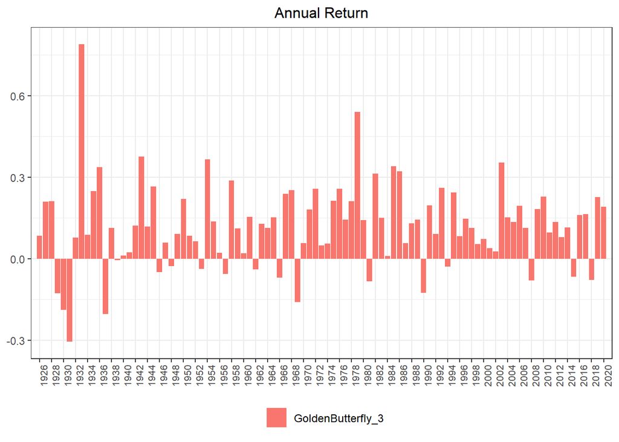

```r
Return.cumulative(port_GoldenButterfly_3)
Return.annualized(port_GoldenButterfly_3)
Return.cumulative(rets_GoldenButterfly_3)
Return.annualized(rets_GoldenButterfly_3)

StdDev.annualized(port_GoldenButterfly_3)
StdDev.annualized(rets_GoldenButterfly_3)

SharpeRatio.annualized(port_GoldenButterfly_3, Rf = rets_GoldenButterfly_3$T.Bills, geometric = TRUE)
SharpeRatio.annualized(rets_GoldenButterfly_3, Rf = rets_GoldenButterfly_3$T.Bills, geometric = TRUE)

maxDrawdown(port_GoldenButterfly_3)
maxDrawdown(rets_GoldenButterfly_3)
```